# Data Wrangling for EDSDers

7-10 Nov, 2022 Tim Riffe Universidad del País Vasco & Ikerbasque (Basque Foundation for Science)

8 Nov, 2022

# 1 Introduction

Flat files refer to large fixed-width format text files that typically contain information on birth, death, and marriage and similar registries. These are commonly produced by Spain, USA, Mexico, and others. Anyone know of other countries that openly share data in this form? Here are two examples:

1. USA https://www.cdc.gov/nchs/data_access/vitalstatsonline.htm
2. Spain [ine.es](https://ine.es/dyngs/INEbase/es/operacion.htm?c=Estadistica_C&cid=1254736177008&menu=resultados&secc=1254736195450&idp=1254735573002) This link for mortality, but there are other pages for marriage, natality, and other things.

Download the USA 2021 Natality file and save it in the `Data` folder (around 200Mb when zipped). It will take up much more memory when we read it in. We’ll just read in selected columns and then do fun things from there. This is really quite fast and easy to do using the `readr` package and browsing the data documentation.

Load packages

```r
library(tidyverse)
library(readr)
```

If you’re daring you can download it from `R` like so, note you need to give it more than the default 60 seconds to download, so we increase the time allowed using `options(timeout = 400)`- you may need more time depending on your connection speed. I just copy-pasted this url. If you download it manually, and prefer that, that’s OK, just extract the text file and run the last bit of code here to g-zip it, then delete the text file.

```r
library(R.utils)
library(here)
file_url <- "https://ftp.cdc.gov/pub/Health_Statistics/NCHS/Datasets/DVS/natality/Nat2021us.zip"

options(timeout=400)
download.file(url = file_url,
              destfile = "Data/nat2021us.zip",
              mode = "wb",
              overwrite = TRUE)

# now unzip it (it's ~5Gb!)
# we use here() because this function apparently wants absolute file paths
unzip(zipfile = here("Data/nat2021us.zip"),
             exdir = here("Data"),
             overwrite = TRUE,
      # TR: I needed to tell it where my unzip program was...YMMV
             unzip = Sys.which("unzip"))

# now re-save as .gz so we can read it directly. This function
# comes from R.utils package...
gzip("Data/nat2021us.txt")

# and go ahead and delete the uncompressed text file.
# You could also delete the zip version..
unlink("Data/nat2021us.txt")
```

# 2 Reading a fixed width file

Give `read_fwf()` a whirl. This worked on the first try after glancing at the options in the help file (type `?read_fwf` in the console).

```r
pos <- fwf_positions(
         start = c(9, 13, 19, 21, 23, 75, 147),
         end = c(12, 14, 20, 22, 23, 76, 148),
         col_names = c("year", "month", "hour","minute","weekday","mage","fage"))

NAT <- read_fwf("Data/nat2021us.txt.gz",
  col_positions = pos,
  col_types = "iiiiiii")

print(object.size(NAT), units ="Mb")
```

```
## 98 Mb
```

The pre-step `fwf_positions()` is a helper function to tell `read_fwf()` where the columns are that we want to extract. This is the quickest and lightest option, since we don’t have to read in the whole dataset, which would max out memory on machines under 4Gb of memory. I got the column positions (`start` and `end` vectors) from the pdf documentation that one can download alongside the data. If the providers were a bit more polite they would provide the column positions in a spreadsheet, but this wasn’t so arduous. By reading in just columns we’re interested in the data object is kept lighter and easier to work with. Data like this really shouldn’t cause hangups when using these tools. There are other tricks one can use for truly large data, but we’ve not got into those.

# 3 Redistribute missing time of day

Check missing time: 332 cases

```r
NAT %>%
  filter(minute == 99,
         hour == 99) %>%
  nrow()
```

```
## [1] 332
```

For the exercises I have in mind it’s probably fine to throw these cases out if using the `time` variable as it’s such a small fraction of births. But we could also redistribute them. In this case how? There are people who dedicate themselves to this question. If we’re lazy we might do so proportional to the distribution of births matched to all the characteristics they have in common. That means we could create a big multidimensional probability distribution of time of day for the combination of knowns for each birth with unknown time of day. It’s laborious, maybe also semirigorous. Even more rigorous would be to include information on other variables you might not be interested in for the redistribution. But the more things you include in the redistribution the smaller the cells get, and it ends up being a bunch of noise and 0s. In that case, you might want to smooth the distribution used to redistribute unknowns, and doing so already puts things in a more statistical setting, where it’s best to take advice from an actual statistician. For problems of this kind, and large count data like these, it’s common to use one or two variables for such redistributions. Dudel and Klüsener (2018) does something similar for missing ages of fathers (rescale by the distribution of known fathers age within each mother age). IMO this is better than imputing means. Before such an exercise we’d want to do a tabulation, which will make these data quite a bit lighter.

```r
NAT <- NAT %>%
  # tabulate by mother age, hour, minute
  group_by(mage, hour, minute) %>%
  summarize(n = n(),
            .groups = "drop") %>%
  # create a "fraction of the day" variable
  mutate(dfrac = ifelse(minute == 99,              # condition
                        NA,                        # true
                        (hour * 60 + minute) / (24*60))) %>% # false
  # changed to retain hour and minute
  select(mage, n, dfrac, hour, minute) %>%
  # whatever we group by is what we redistribute within
  group_by(mage) %>%
  # what is the fraction of births in each time-of-day within each mother age?
  mutate(bfrac = n / sum(n[!is.na(dfrac)]),
         n = n + bfrac * # multiply into birth of unknown time
                   ifelse(
                     sum(is.na(dfrac)) == 0, # condition
                     0,                      # true
                     n[is.na(dfrac)])) %>%   # false
  ungroup() %>%
  # now remove the NA times
  filter(!is.na(dfrac))# %>%
  # no need to recreate, could have retained them in the first place.
  # and get minute / hour back from the day fraction
  # mutate(minute = floor((dfrac * (60 * 24)) %% 60),
  #        hour = floor((dfrac * (60 * 24)) - minute))

# demonstration of why we need the second ifelse() statement
# a <- c(1,4,56,6,76,5)
# a[is.na(a)] * 1
```

# 4 Visualize it: surface

Now we’ve redistributed births of unknown time of day according to the distribution of known time of day within each mother age. The *within* part of this was dealt with by the `group_by(mage)` statement, where one could add another variable or two to make it finer. However, already for mother age under ca 15 or over ca 35, we’re not filling each minute of the day with observations. Were we to zoom in we might even observe minute heaping…

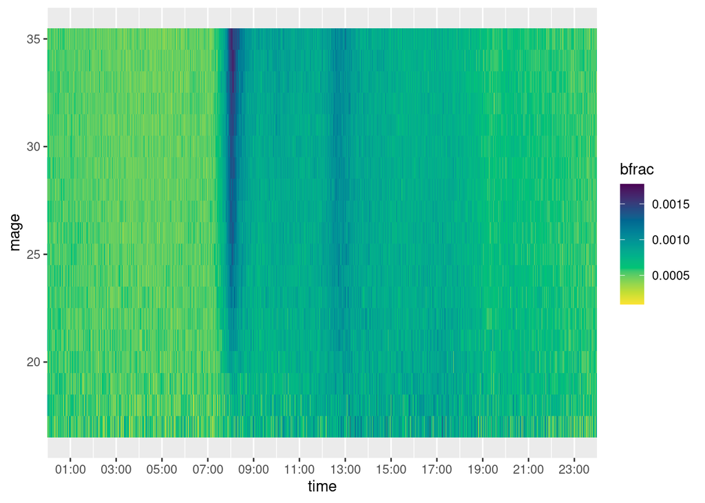

```r
library(lubridate)
library(colorspace)
logit <- function(x){
  log(x/(1-x))
}

NAT %>%
  mutate(time = paste(hour, minute, sep = ":"),
         time = as.POSIXct(time, format = "%H:%M")) %>%
  filter(mage >= 17,
         mage <= 35) %>%
  ggplot(mapping = aes(x = time, y = mage, fill = bfrac)) +
  geom_tile() +
  scale_fill_continuous_sequential("Viridis") +
  scale_x_datetime(date_breaks="2 hour", date_labels="%H:%M", expand = c(0,0))
```

You’ll note a two-step `mutate()` call that defines the `time` variable out of hours and minutes. In order to get `ggplot()` to render x axis as properly formatted hours, it’s a good idea to convert our integer representation of hours and minutes into a real time class. Time classes are varied and tricky. From `ggplot()` warnings I learned the `POSIXct` format was needed, and a this StackOverflow answer gave me what I needed to fix it https://learnr.wordpress.com/2010/02/25/ggplot2-plotting-dates-hours-and-minutes/, so now the x axis looks good in the plot.

# 5 Visualize it: ridgeplot

We trucate `mage` in order to remove noise that might distort the pattern, but we could recover more of the surface if it were smoothed. We might be able to recover more definition in the time of day pattern if it were represented as lines. Let’s see:

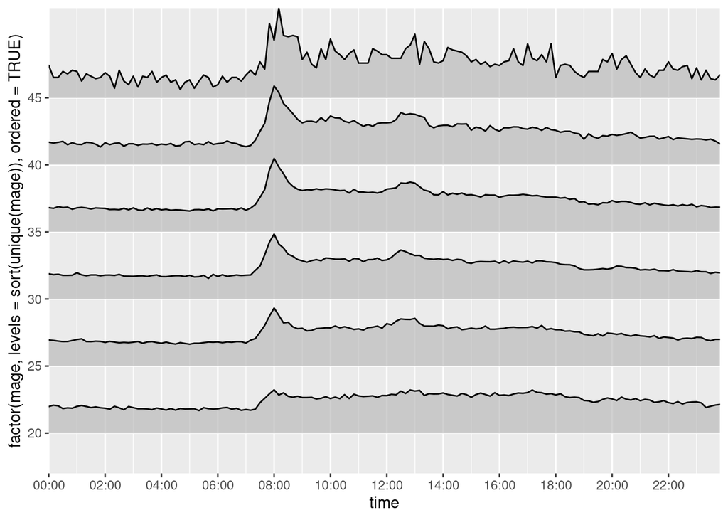

```r
library(ggridges)
NAT %>%
  # first group to 10 min intervals, minute precision is the source
  # of much of our noise problem
  mutate(min10 = minute - minute %% 10) %>%
  group_by(mage, hour, min10) %>%
  summarize(bfrac = sum(bfrac),
            .groups = "drop") %>%
  ungroup() %>%
  # now declare hourmin time variable
  mutate(time = paste(hour, min10, sep = ":"),
         time = as.POSIXct(time, format = "%H:%M")) %>%
  # select age range of interest
  filter(mage %% 5 == 0,
         mage >= 20,
         mage < 50) %>%
  # ridgeplot following form of previous lesson
  ggplot(mapping = aes(x = time,
                       y = factor(mage,
                                  levels = sort(unique(mage)),
                                  ordered = TRUE))) +
    geom_ridgeline(mapping = aes(x = time,
                                               height = bfrac),
                   scale = 70,
                         alpha = .6) +
  scale_x_datetime(date_breaks="2 hour", date_labels="%H:%M", expand = c(0,0))
```

OK, we could sense some of this variation in the surface plot, but here it’s a but clearer I think: the 8:00 peak gets sharper as mother age increases, and the 13:00 also emerges with age.

If you don’t know what you want to do for your assignment, you might ask: how much of this pattern is due to cesarians? For that, just repeat the same thing twice and plot a double-ridge as we did for ASFR: if they don’t overlap it’ll be obvious. Does this pattern have month seasonality? It is identical for boy and girl births? This is very rich data and you’re sure to find something interesting in it.

Do you find this data too noisy when plotted by single minutes? Try grouping to 5-minute bins. Recall the modulo trick (`%%`).

Or you could aggregate for a few years and tell me whether the distribution has changed over time. Or during the pandemic?

Or you could look at the birth weight distribution by …. You get the idea, there are tons of exremely interesting things you could explore and plot in this data, any of which would suffice for an assignment.

# References

Dudel, Christian, and Sebastian Klüsener. 2018. “Estimating Men’s Fertility from Vital Registration Data with Missing Values.” *Population Studies*, 1–11.